# O-ACE POP Analysis

[Matti Vuorre](https://vuorre.netlify.app)

[University of Oxford](https://www.oii.ox.ac.uk/people/matti-vuorre/)

2022-05-09

# Preface

This document describes the O-ACE POP study data analyses. The data and code underlying these analyses are available at https://osf.io/9wt8d/.

We used the following R packages.

```r
library(knitr)
library(scales)
library(janitor)
library(flextable)
library(officer)
library(gtsummary)
library(ggbeeswarm)
library(kableExtra)
library(broom)
library(afex)
library(emmeans)
library(cowplot)
library(ggstance)
library(patchwork)
library(readxl)
library(tidyverse)

# Document options
# Knitr options
opts_chunk$set(
  echo = FALSE,
  warning = FALSE,
  cache = TRUE,
  error = FALSE,
  message = FALSE,
  fig.align = "center",
  fig.retina = 2
)
# Plotting theme
theme_set(
  theme_linedraw() +
    theme(
      panel.grid.minor = element_blank(),
      panel.grid.major.x = element_blank()
    )
)
# gtsummary theme
theme_gtsummary_compact(set_theme = TRUE)

# Temporary output files
dir.create("output", FALSE)
```

The survey data is contained in `.xlsx` files in `Data/`. Here we load and clean the data tables.

# Demographics

First, a table of aggregate demographics. Note the data underlying this table is not shared due to small cell sizes and potential identifiability.

Table 1: Table 1: Demographics

| Characteristic | Overall, N = 4631 | Ash, N = 2321 | WoB, N = 2311 |
| --- | --- | --- | --- |
| Age |  |  |  |
| 16-17 | 41 (8.9%) | 15 (6.5%) | 26 (11%) |
| 18-24 | 422 (91%) | 217 (94%) | 205 (89%) |
| Gender |  |  |  |
| Female | 276 (60%) | 138 (59%) | 138 (60%) |
| Male | 179 (39%) | 90 (39%) | 89 (39%) |
| Other/ prefer not to say | 8 (1.7%) | 4 (1.7%) | 4 (1.7%) |
| Ethnicity |  |  |  |
| Asian British (Indian Pakistani or Bangladeshi) | 33 (7.1%) | 18 (7.8%) | 15 (6.5%) |
| Black/Black British (Caribbean African or Other) | 22 (4.8%) | 11 (4.7%) | 11 (4.8%) |
| Chinese/Chinese British | 10 (2.2%) | 5 (2.2%) | 5 (2.2%) |
| Mixed race (Other) | 17 (3.7%) | 6 (2.6%) | 11 (4.8%) |
| Mixed race (White and Black/Black British) | 15 (3.2%) | 9 (3.9%) | 6 (2.6%) |
| Other/prefer not to say | 6 (1.3%) | 3 (1.3%) | 3 (1.3%) |
| White (British Irish or Other) | 360 (78%) | 180 (78%) | 180 (78%) |
| Occupation |  |  |  |
| At school | 48 (10%) | 23 (9.9%) | 25 (11%) |
| In full-time employment (not studying) | 113 (24%) | 64 (28%) | 49 (21%) |
| In part-time employment (not studying) | 84 (18%) | 45 (19%) | 39 (17%) |
| On furlough (not studying) | 14 (3.0%) | 4 (1.7%) | 10 (4.3%) |
| Other | 27 (5.8%) | 13 (5.6%) | 14 (6.1%) |
| Studying and not working | 113 (24%) | 56 (24%) | 57 (25%) |
| Studying and working | 64 (14%) | 27 (12%) | 37 (16%) |
| Relationship |  |  |  |
| In a relationship/Living with partner | 85 (18%) | 43 (19%) | 42 (18%) |
| In a relationship/Not living with partner | 146 (32%) | 74 (32%) | 72 (31%) |
| Other | 6 (1.3%) | 2 (0.9%) | 4 (1.7%) |
| Single | 226 (49%) | 113 (49%) | 113 (49%) |
| Household_income |  |  |  |
| £16 000 - £29 999 a year | 81 (17%) | 44 (19%) | 37 (16%) |
| £30 000 - £59 999 a year | 144 (31%) | 67 (29%) | 77 (33%) |
| Less than £16 000 a year | 88 (19%) | 44 (19%) | 44 (19%) |
| More than £60 000 a year | 115 (25%) | 62 (27%) | 53 (23%) |
| Prefer not to say | 35 (7.6%) | 15 (6.5%) | 20 (8.7%) |
| OCC_Engagement_Frequency |  |  |  |
| Between once a month and once a year | 156 (34%) | 76 (33%) | 80 (35%) |
| More than once a month (but less than once a week) | 115 (25%) | 59 (25%) | 56 (24%) |
| Once a week or more | 123 (27%) | 62 (27%) | 61 (26%) |
| Rarely/Never (No more than once a year) | 69 (15%) | 35 (15%) | 34 (15%) |
| Current_Mental_Health |  |  |  |
| No | 218 (47%) | 114 (49%) | 104 (45%) |
| Yes | 245 (53%) | 118 (51%) | 127 (55%) |
| Current_Health |  |  |  |
| No | 393 (85%) | 202 (87%) | 191 (83%) |
| Yes | 70 (15%) | 30 (13%) | 40 (17%) |
| Covid_19_Diagnosis |  |  |  |
| No | 367 (79%) | 190 (82%) | 177 (77%) |
| Suspected and recovered | 43 (9.3%) | 10 (4.3%) | 33 (14%) |
| Suspected and still ill | 22 (4.8%) | 11 (4.7%) | 11 (4.8%) |
| Yes diagnosed and recovered | 24 (5.2%) | 18 (7.8%) | 6 (2.6%) |
| Yes diagnosed and still ill | 7 (1.5%) | 3 (1.3%) | 4 (1.7%) |
| Isolation_Status |  |  |  |
| I am leaving the house as normal | 64 (14%) | 31 (13%) | 33 (14%) |
| I am leaving the house for work/essential responsibilities but practising social distancing where possible | 183 (40%) | 87 (38%) | 96 (42%) |
| I am leaving the house only for essential supplies and daily exercise | 149 (32%) | 75 (32%) | 74 (32%) |
| I am not leaving the house at all and have no access to outside space | 22 (4.8%) | 14 (6.0%) | 8 (3.5%) |
| I am not leaving the house at all but have access to outside space (e.g. garden) | 45 (9.7%) | 25 (11%) | 20 (8.7%) |
| Antidepressant |  |  |  |
| No | 363 (78%) | 175 (75%) | 188 (81%) |
| Yes | 100 (22%) | 57 (25%) | 43 (19%) |
| Baseline_mild_MH2 |  |  |  |
| No | 355 (77%) | 172 (74%) | 183 (79%) |
| Yes | 108 (23%) | 60 (26%) | 48 (21%) |
| Baseline_moderate_MH2 |  |  |  |
| No | 327 (71%) | 167 (72%) | 160 (69%) |
| Yes | 136 (29%) | 65 (28%) | 71 (31%) |
| Baseline_severe_MH2 |  |  |  |
| No | 294 (63%) | 146 (63%) | 148 (64%) |
| Yes | 169 (37%) | 86 (37%) | 83 (36%) |

1n (%)  
2Mild, moderate, and severe MH: A score of 20-24 was defined as being consistent with probable mild disorder, 25-29 with a probable moderate disorder and 30 and over with a probable severe disorder.

Then we create a table of demographics for the subgroup analyses.

We also create a synthetic demographics table for sharing on OSF, with only the PIDs and group assignments reflecting real values, and the actual demographics values are simulated (due to small cell sizes and potential identifiability of participants).

Then we load either the actual demographics values if available (only available to OACE team), otherwise the simulated demographics table (available on OSF).

| **Characteristic** | **Overall**, N = 463<sup>1</sup> | **Ash**, N = 232<sup>1</sup> | **WoB**, N = 231<sup>1</sup> |
| --- | --- | --- | --- |
| Age1617 | 41 (8.9%) | 15 (6.5%) | 26 (11%) |
| Male | 179 (39%) | 90 (39%) | 89 (39%) |
| Antidepressant | 100 (22%) | 57 (25%) | 43 (19%) |
| Relationship | 231 (50%) | 117 (50%) | 114 (49%) |
| White | 375 (81%) | 189 (81%) | 186 (81%) |
| OCC_Engagement | 238 (51%) | 121 (52%) | 117 (51%) |
| Baseline_moderate_MH | 136 (29%) | 65 (28%) | 71 (31%) |

<sup>*1*</sup> n (%)

Clean data sets more and add demographics variables (covariates & subgroups).

# Main analysis

## Means and change over time

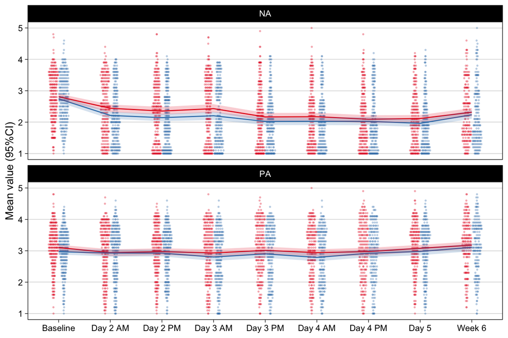

Figure 1: PANAS over time.

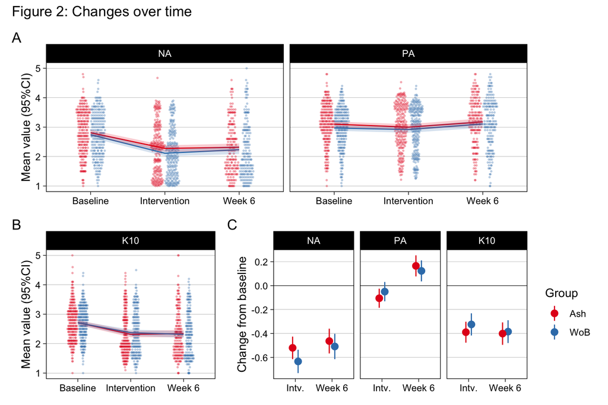

Figure 2: PANAS and K10 means and change over time.

Means with bootstrapped CIs in numbers

Table 2: Means

| Outcome | Time | y | ymin | ymax |
| --- | --- | --- | --- | --- |
| NA | Baseline | 2.8 | 2.7 | 2.8 |
| NA | Intervention | 2.2 | 2.1 | 2.3 |
| NA | Week 6 | 2.3 | 2.2 | 2.4 |
| PA | Baseline | 3.0 | 3.0 | 3.1 |
| PA | Intervention | 3.0 | 2.9 | 3.0 |
| PA | Week 6 | 3.1 | 3.0 | 3.2 |
| K10S | Baseline | 27.1 | 26.6 | 27.7 |
| K10S | Intervention | 23.4 | 22.7 | 24.2 |
| K10S | Week 6 | 23.3 | 22.4 | 24.1 |

Change from baseline in numbers

Table 3: Change from baseline

| Group | Outcome | Time | estimate | SE | lower.CL | upper.CL | p.value |
| --- | --- | --- | --- | --- | --- | --- | --- |
| WoB | NA | Intervention | -0.634 | 0.050 | -0.732 | -0.536 | 0.000 |
| WoB | NA | Week 6 | -0.509 | 0.054 | -0.615 | -0.403 | 0.000 |
| WoB | PA | Intervention | -0.050 | 0.041 | -0.131 | 0.031 | 0.224 |
| WoB | PA | Week 6 | 0.123 | 0.045 | 0.036 | 0.211 | 0.006 |
| WoB | K10 | Intervention | -0.324 | 0.047 | -0.417 | -0.232 | 0.000 |
| WoB | K10 | Week 6 | -0.385 | 0.048 | -0.480 | -0.289 | 0.000 |
| Ash | NA | Intervention | -0.520 | 0.048 | -0.614 | -0.426 | 0.000 |
| Ash | NA | Week 6 | -0.464 | 0.053 | -0.567 | -0.360 | 0.000 |
| Ash | PA | Intervention | -0.105 | 0.041 | -0.185 | -0.025 | 0.010 |
| Ash | PA | Week 6 | 0.165 | 0.045 | 0.077 | 0.253 | 0.000 |
| Ash | K10 | Intervention | -0.389 | 0.045 | -0.477 | -0.302 | 0.000 |
| Ash | K10 | Week 6 | -0.401 | 0.048 | -0.495 | -0.308 | 0.000 |

## Clinically significant symptoms

Table 4: Percentages of individuals with clinically significant symptoms

| Time | Group | n | K10 > 19 |
| --- | --- | --- | --- |
| Baseline | Ash | 232 | 90.9% |
| Baseline | WoB | 231 | 87.4% |
| Intervention | Ash | 206 | 57.3% |
| Intervention | WoB | 191 | 62.8% |
| Week 6 | Ash | 172 | 59.3% |
| Week 6 | WoB | 177 | 62.1% |

## Group differences

We estimate group differences with a multilevel model of each outcome, using baseline outcome (mean centered), group indicator (0/1 coded), and contrast coded (-0.5, 0.5) covariates age, gender, ethnicity, relationship, and current antidepressant use as predictors. In addition, we used timepoint and all its interactions as a predictor to get timepoint specific group effects.

Table 5: Time point specific ANCOVA model results for each of the main outcomes.

| Outcome | contrast | Time | estimate | SE | lower.CL | upper.CL | t.ratio | p.value | N |
| --- | --- | --- | --- | --- | --- | --- | --- | --- | --- |
| NA | WoB - Ash | Intervention | -0.158 | 0.061 | -0.278 | -0.038 | -2.592 | 0.010 | 448 |
| NA | WoB - Ash | Week 6 | -0.090 | 0.068 | -0.223 | 0.044 | -1.319 | 0.187 | 448 |
| PA | WoB - Ash | Intervention | 0.031 | 0.055 | -0.076 | 0.139 | 0.569 | 0.570 | 448 |
| PA | WoB - Ash | Week 6 | -0.083 | 0.060 | -0.200 | 0.034 | -1.387 | 0.166 | 448 |
| K10 | WoB - Ash | Intervention | 0.069 | 0.060 | -0.048 | 0.186 | 1.158 | 0.247 | 397 |
| K10 | WoB - Ash | Week 6 | 0.015 | 0.063 | -0.109 | 0.140 | 0.241 | 0.809 | 397 |

## Subgroup analyses

The subgroup analyses are conducted on each outcome over the intervention phase (for NA and PA averaged over the intervention phase time points and K10at day 5).

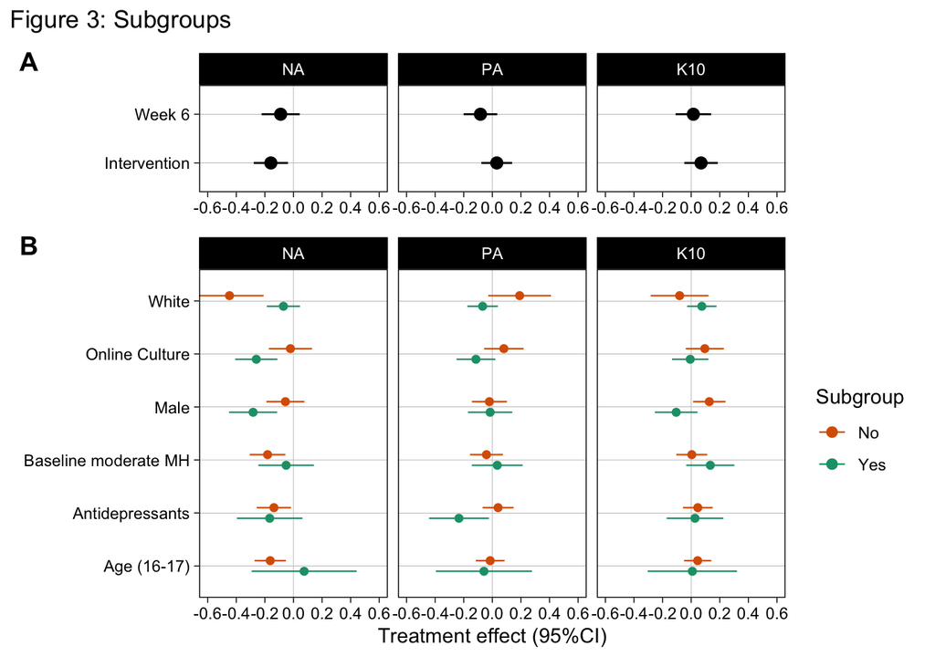

Figure 3: A) Treatment effect (WoB - Ash) at each time point for the main outcomes. B) Treatment effect for each subgroup included in the analyses (on the mean outcome during the intervention).

# Flourishing & Loneliness

## Means and change over time

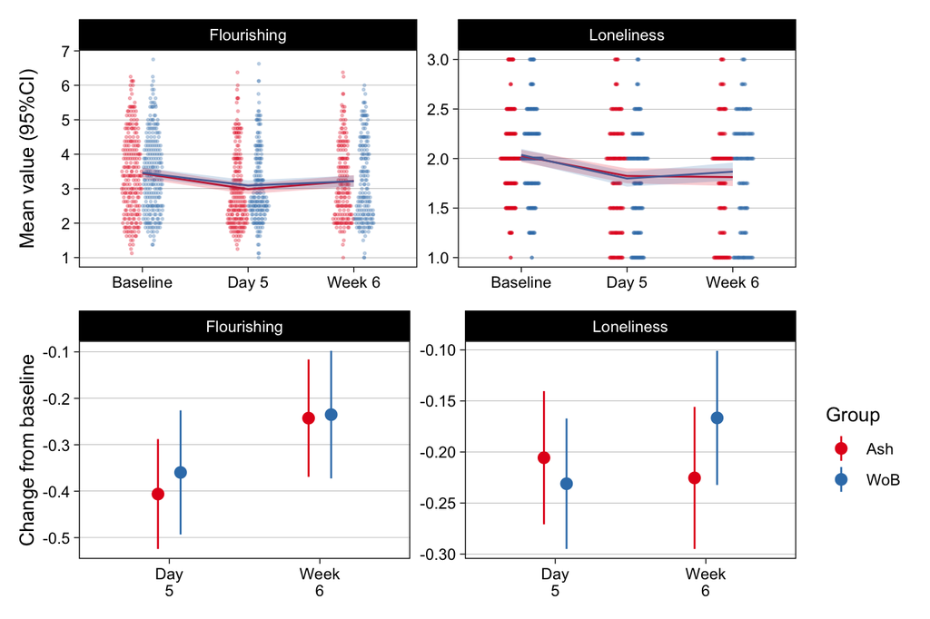

Figure 4: Flourishing and Loneliness means and change over time.

## Group differences

Table 6: Time point specific ANCOVA model results.

| Outcome | contrast | Time | estimate | SE | lower.CL | upper.CL | p.value | N |
| --- | --- | --- | --- | --- | --- | --- | --- | --- |
| Flourishing | WoB - Ash | Day 5 | 0.053 | 0.080 | -0.105 | 0.211 | 0.512 | 397 |
| Flourishing | WoB - Ash | Week 6 | 0.003 | 0.085 | -0.163 | 0.170 | 0.970 | 397 |
| Loneliness | WoB - Ash | Day 5 | -0.026 | 0.047 | -0.118 | 0.067 | 0.586 | 397 |
| Loneliness | WoB - Ash | Week 6 | 0.064 | 0.049 | -0.032 | 0.160 | 0.194 | 397 |